# individual1

Brett Santema

2/11/2020

Note: I did not have a partner for this lab as I wasn’t able to make it to class, but I am submitting individual answers to everything for partial credit.

```r
choco <- read.csv("https://xdaiisu.github.io/ds202materials/hwlabs/choco.csv")
head(choco)
```

```
##    Company Specific.Bean.Origin  REF Review.Date Cocoa.Pct Company.Location
## 1 A. Morin          Agua Grande 1876        2016        63           France
## 2 A. Morin                Kpime 1676        2015        70           France
## 3 A. Morin               Panama 1011        2013        70           France
## 4 A. Morin           Madagascar 1011        2013        70           France
## 5 A. Morin               Brazil 1011        2013        70           France
## 6 A. Morin             Equateur 1011        2013        70           France
##   Rating Bean.Type Broad.Bean.Origin
## 1   3.75                    Sao Tome
## 2   2.75                        Togo
## 3   2.75                      Panama
## 4   3.00   Criollo        Madagascar
## 5   3.25                      Brazil
## 6   3.75                     Ecuador
```

## 1. How are ratings dsitrubuted?

The ratings are mostly clusterd around the center, with the majority of ratings being between 2.5 and 3.5. The are almost no ratings above 4, but there are a considerable amount of rating between 1 and 2.5. Overall, the ratings seem a bit skewed towards the unsatisfactory side.

## Draw a histogram of the ratings and describe it.

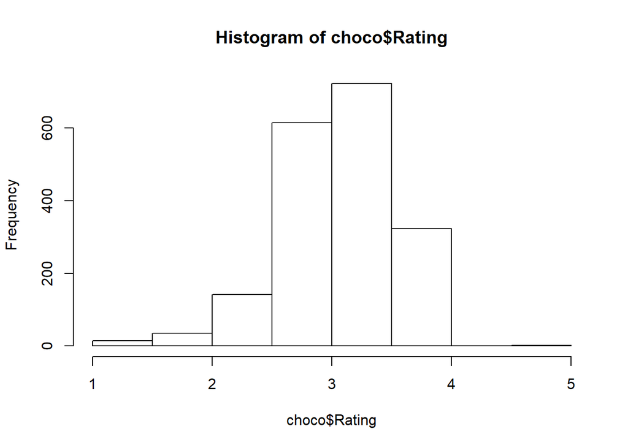

```r
hist(choco$Rating)
```

## 2. Do ratings depend on the cacao percentage of a chocolate bar?

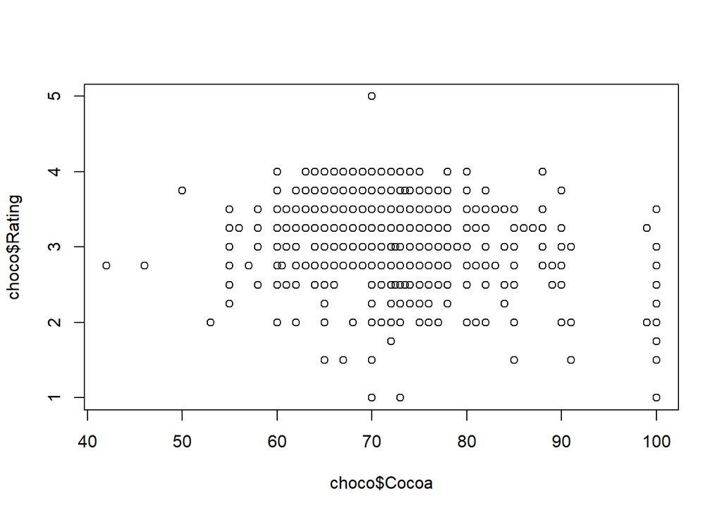

```r
plot(choco$Cocoa, choco$Rating)
```

Based on the scatterplot, no, the ratings don’t depend on the actual cacao percentage in the chocolate bar.

## What is the overall number of chocolate bars rated?

```r
nrow(choco)
```

```
## [1] 1852
```

## How does the number of ratings depend on the year?

As can be seen by the bar chart below, the number of ratings has increased over time. However, there are not many ratings for the most recent year, which might be because the year is not over yet or the ratings are still being processed.

## Draw a bar chart of the number of reports.

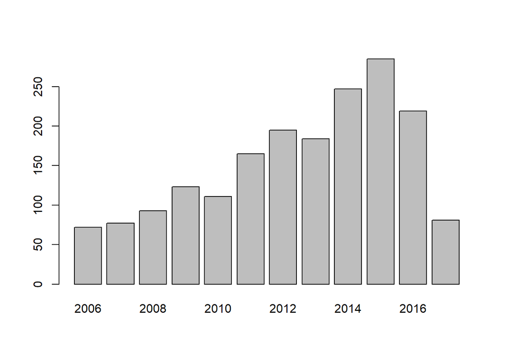

```r
yearCounts <- table(choco$Review.Date)
barplot(yearCounts)
```

## Which are the three locations with the most ratings? How do ratings compare across these company locations?

```r
sort(table(choco$Company.Location), decreasing = TRUE)
```

```
##
##            U.S.A.            France            Canada              U.K.
##               787               158               132                98
##             Italy           Ecuador         Australia           Belgium
##                69                55                50                40
##       Switzerland           Germany           Austria             Spain
##                38                36                27                26
##          Colombia           Hungary         Venezuela            Brazil
##                23                23                20                18
##             Japan        Madagascar       New Zealand              Peru
##                17                17                17                17
##           Denmark           Vietnam         Guatemala          Scotland
##                16                11                10                10
##         Argentina        Costa Rica            Israel            Poland
##                 9                 9                 9                 8
##         Amsterdam          Honduras         Lithuania Domincan Republic
##                 6                 6                 6                 5
##         Nicaragua       South Korea            Sweden              Fiji
##                 5                 5                 5                 4
##           Ireland            Mexico       Netherlands       Puerto Rico
##                 4                 4                 4                 4
##          Sao Tome            U.A.E.           Grenada           Iceland
##                 4                 4                 3                 3
##          Portugal            Russia         Singapore      South Africa
##                 3                 3                 3                 3
##           Bolivia             Chile           Finland             India
##                 2                 2                 2                 2
##         St. Lucia    Czech Republic           Eucador             Ghana
##                 2                 1                 1                 1
##        Martinique         Niacragua       Philippines          Suriname
##                 1                 1                 1                 1
##             Wales
##                 1
```

```r
mean(choco$Rating[choco$Company.Location == "U.S.A."])
```

```
## [1] 3.162325
```

```r
mean(choco$Rating[choco$Company.Location == "France"])
```

```
## [1] 3.253165
```

```r
mean(choco$Rating[choco$Company.Location == "Canada"])
```

```
## [1] 3.3125
```

The highest average ratings are from Canada, followed by France, then the USA.

## Brainstorm/write down an interesting question about the dataset.

Is there a relationship between the origin of the beans and the number of reviews for chocolates with that bean origin?

## Answer the question

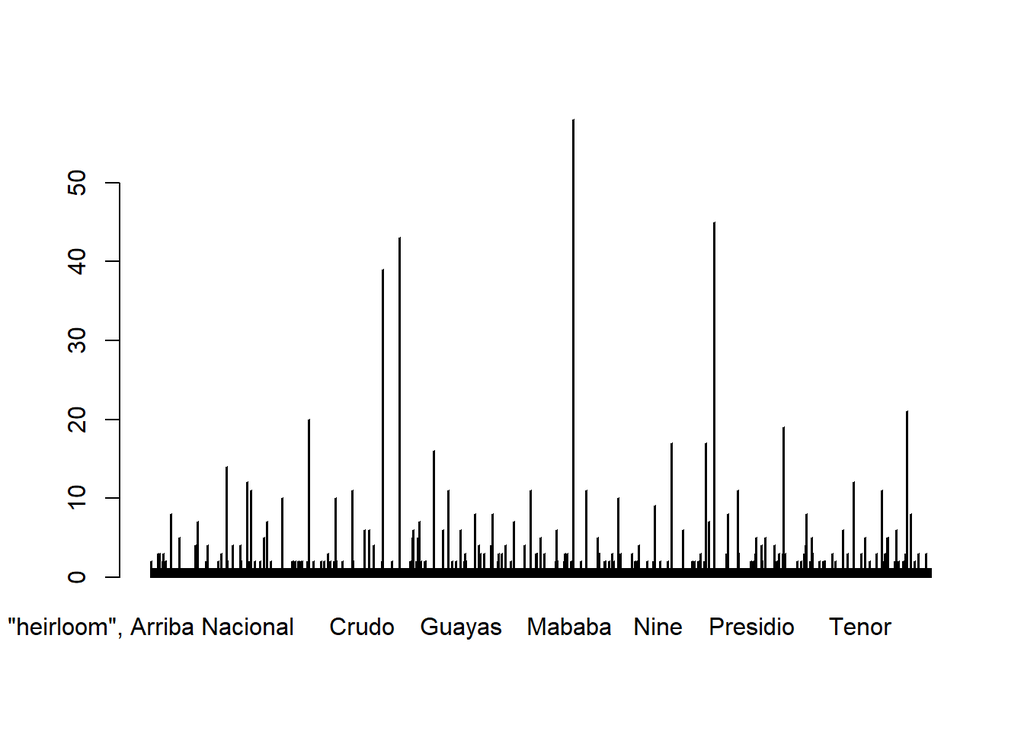

```r
beans <- table(choco$Specific.Bean.Origin)
barplot(beans)
```

```r
head(sort(table(choco$Specific.Bean.Origin), decreasing = TRUE))
```

```
##
##         Madagascar               Peru            Ecuador Dominican Republic
##                 58                 45                 43                 39
##          Venezuela              Chuao
##                 21                 20
```